← Back to R & Statistics

# Cancer Detection - Two-way ANOVA

```r
library(mosaic)
library(DT)
library(pander)
library(car)
library(tidyverse)
library(writexl)

# Record your data from your own mini experiment in Excel.
# Save the data as a .csv file in the Data folder of the Statistics-Notebook.

#ChatGpt

# Read in the data
cancerDetectionData <- read_csv("cancer_detection_data.csv")
```

### Background

This dataset was generated as part of a simulated analysis for a two-way ANOVA in the context of cancer detection. The dataset consists of the effects of two factors—treatment type and gender—on a cancer detection score.

Treatment type has two levels:

- **Chemotherapy**
- **Radiation.**

Gender has two levels:

- **Male**
- **Female.**

The cancer detection score is a continuous variable representing the test results or effectiveness of the treatment, with scores generated randomly for each combination of treatment type and gender. The dataset was created for the sake of this project using R and ChatGPT. It serves as a randomly generated dataset for conducting a statistical analysis using a two-way ANOVA to explore the impact of treatment type and gender on cancer detection.

see the head of the data below:

```r
cancerDetectionData <- cancerDetectionData |>
  mutate(Treatment = as.factor(Treatment),
         Gender = as.factor(Gender))
datatable(cancerDetectionData)
```

|  | Treatment | Gender | Score |
| --- | --- | --- | --- |
| 1 | Chemotherapy | Male | 54.39524353 |
| 2 | Chemotherapy | Female | 57.69822511 |
| 3 | Chemotherapy | Male | 75.58708314 |
| 4 | Chemotherapy | Female | 60.70508391 |
| 5 | Chemotherapy | Male | 61.29287735 |
| 6 | Chemotherapy | Female | 77.15064987 |
| 7 | Chemotherapy | Male | 64.60916206 |
| 8 | Chemotherapy | Female | 47.34938765 |
| 9 | Chemotherapy | Male | 53.13147148 |
| 10 | Chemotherapy | Female | 55.5433803 |

[output cut: 110 more lines]

```r
#head(cancerDetectionData) |> pander(caption = "Cancer Detection dataset")
```

### Hypotheses

1. Does the treatment type has an effect on the cancer detection score?

$$H_o: \mu_\text{Chemotherapy} = \mu_\text{Radiation}$$
$$H_a: \mu_\text{Chemotherapy} \neq \mu_\text{Radiation}$$
2. Does the cancer detection score defers based on Gender?

$$H_o: \mu_\text{Male} = \mu_\text{Female}$$
$$H_a: \mu_\text{Male} \neq \mu_\text{Female}$$

3. Does the choice of a treatment affects the cancer detection score different based on the gender?

$$H_o: \text{The treatment type has the same effect on the score for
both males and females }$$
$$H_a: \text{The treatment type doesn't have the same effect on the
score for males and females }$$
*The level of significance is $\alpha = 0.05$*

### Analysis

#### Two Way ANOVA

```r
cancer_aov <- aov(Score ~ Treatment+Gender+Gender:Treatment, data = cancerDetectionData)
summary(cancer_aov) |> pander(caption = "Cancer Detection Analyses of Variance (ANOVA)")
```

Cancer Detection Analyses of Variance (ANOVA)

|  | Df | Sum Sq | Mean Sq | F value | Pr(>F) |
| --- | --- | --- | --- | --- | --- |
| **Treatment** | 1 | 208.6 | 208.6 | 2.285 | 0.1333 |
| **Gender** | 1 | 3.975 | 3.975 | 0.04355 | 0.8351 |
| **Treatment:Gender** | 1 | 22.6 | 22.6 | 0.2476 | 0.6197 |
| **Residuals** | 116 | 10589 | 91.28 | NA | NA |

Based on the above table, we notice that the p-value of the hypotheses in relation with the treatment type is 0.1333, which is not significant. It means that the choice of a specific treatment doesn’t not affect the cancer score detected. Likewise with the gender and the choice of a treatment doesn’t difer from male to females on the score.

### Dignosis Plots

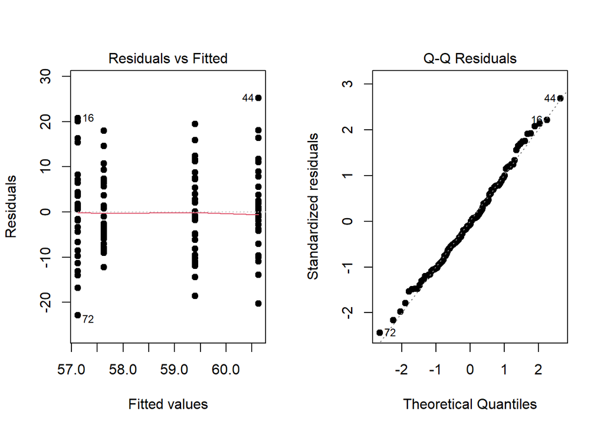

```r
par(mfrow = c(1,2))
plot(cancer_aov, which = 1:2, pch = 19)
```

The Q-Q plot demonstrates that the distribution of the error is normally distributed. The residual vs fitted chart shows that the variances are constant. from these two chart, we can conclude that the assumption for conducting an ANOVA are met for this dataset.

### Graphical Summary and Conclusion

Since the ANOVA analysis shows that the differents factors of each group( Gender and treatment type) do not have effect on the cancer detection score, let see if the graph confirm verifuy this statement.

*Treatment Type*

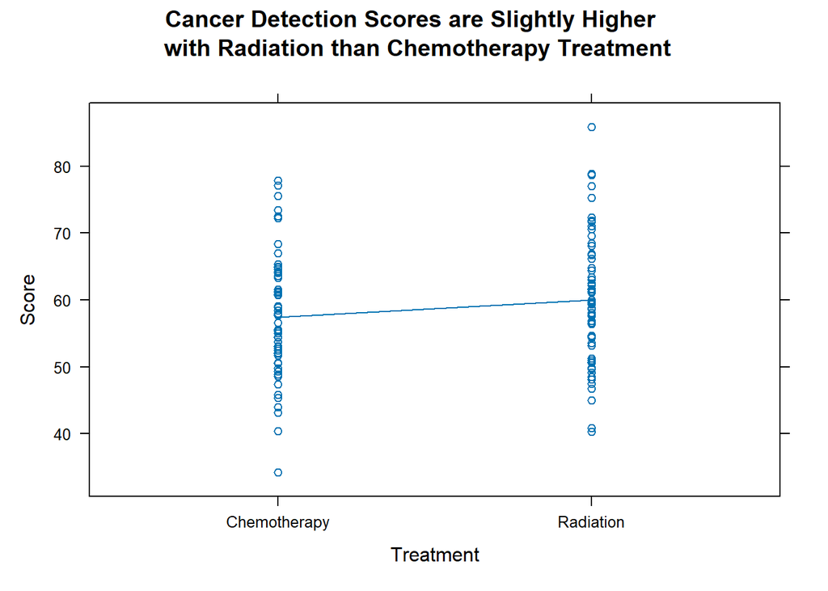

```r
xyplot(Score ~ Treatment, data = cancerDetectionData, type=c("p", "a"),
       main = "Cancer Detection Scores are Slightly Higher \n with Radiation than Chemotherapy Treatment")
```

```r
cancerDetectionData |>
  group_by(Treatment) |>
  summarise(Mean_core = mean(Score)) |>
  pander(caption = "Score by Treatment type")
```

Score by Treatment type

| Treatment | Mean_core |
| --- | --- |
| Chemotherapy | 57.37 |
| Radiation | 60.01 |

The mean scores by treatment type show a slight difference, with an overall average of about 58.69. The largest deviation from this overall mean is approximately 1.32 points (Radiation mean: 60.01). While Radiation shows slightly higher scores compared to Chemotherapy, the difference is still relatively small, suggesting the treatment type has only a minor effect on cancer detection scores.

.

*Gender*

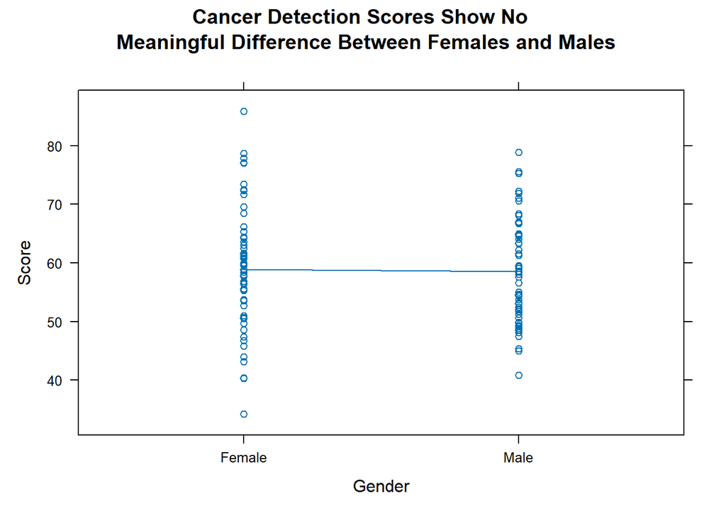

```r
xyplot(Score ~ Gender, data = cancerDetectionData, type=c("p", "a"),
       main = "Cancer Detection Scores Show No \n Meaningful Difference Between Females and Males")
```

```r
cancerDetectionData |>
  group_by(Gender) |>
  summarise(Mean_core = mean(Score)) |>
  pander(caption = "Score by Gender")
```

Score by Gender

| Gender | Mean_core |
| --- | --- |
| Female | 58.87 |
| Male | 58.51 |

The mean scores by gender are very similar and show minimal difference. The overall average score across both genders is approximately 58.69. The largest deviation from this overall mean is just 0.18 points (Female mean: 58.87). Therefore, we can conclude that gender has very little or no meaningful effect on the cancer detection scores.

*Effect of both Treatment type and Gender*

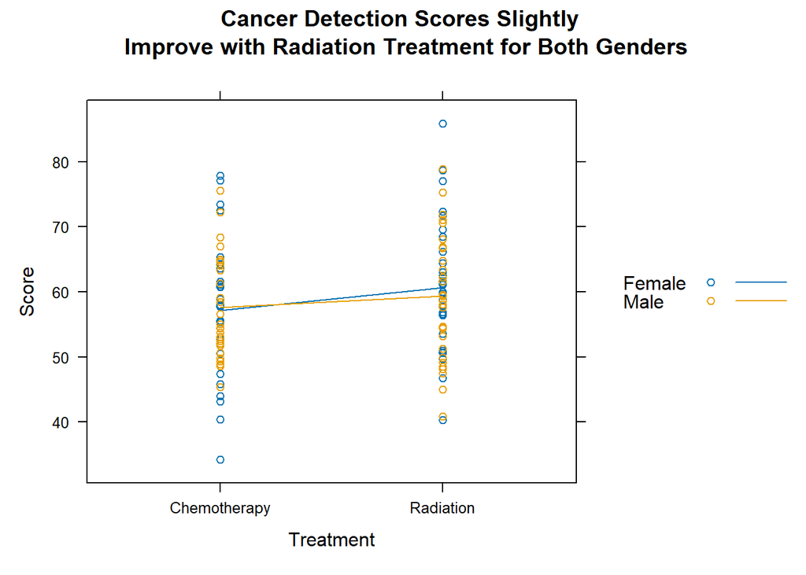

```r
xyplot(Score ~ Treatment, groups = Gender, data = cancerDetectionData,type = c("p", "a"), auto.key = TRUE,
       main = "Cancer Detection Scores Slightly \n Improve with Radiation Treatment for Both Genders")
```

```r
cancerDetectionData |>
  group_by(Treatment, Gender) |>
  summarise(mean_Cancer_Detection = mean(Score), .groups = "drop") |>
  pander(caption = "Summary Table")
```

Summary Table

| Treatment | Gender | mean_Cancer_Detection |
| --- | --- | --- |
| Chemotherapy | Female | 57.12 |
| Chemotherapy | Male | 57.63 |
| Radiation | Female | 60.63 |
| Radiation | Male | 59.4 |

### Conclusion

Based on the data provided, there are minor variations in cancer detection scores between treatment types and genders. However, these differences are not statistically significant, suggesting that the effect of treatment on cancer detection does not depend on gender

### Note

- *“This work is modeled after the [warpbreaks](https://byuistats.github.io/Statistics-Notebook/Analyses/ANOVA/Examples/warpbreaksTwoWayANOVA.html) analysis.”*
- I used ChatGPT to correct my grammatical errors